# Praca domowa 5

Jakub Wiśniewski

04/12/2019

# Wstęp

Link do ankiety: https://forms.gle/dRNzcJ4d5VB6HPs48

Ankieta którą przeporwadziłem miała za zadanie pokazać 3 rzeczy:

1. Sprawdzić jakie rzeczy przeszkadzają ludziom w wykresach
2. Zobaczyć które typy wykresów chcą zobaczyć ludzie
3. Sprawdzić czy wykresy ozdobione (1 wykres) bardziej zapadają w pamięć niż wykresy przedstawiające surowe dane (2,3 wykres). Moim ten aspekt jest najciekawszy, bo ankieta została zaprojektowana w ten sposób by przyjrzeć się wykresom, ale niekoniecznie skupiać się na ich zapamiętaniu.

W badaniu wzięło udział 16 osób

# Wyniki:

## Wykres 1

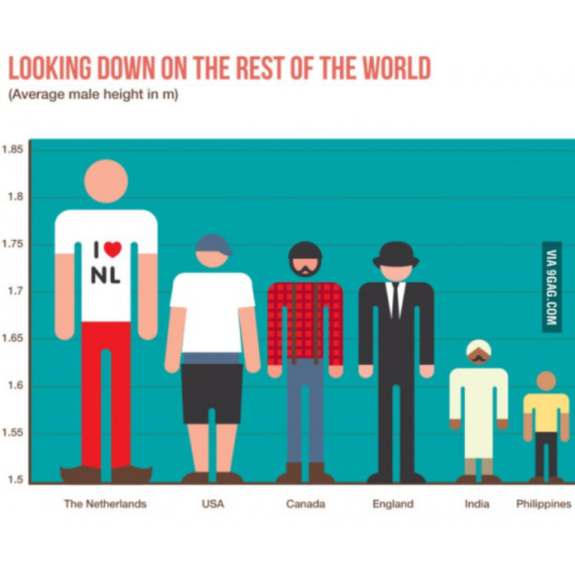

Odpowiedzi:

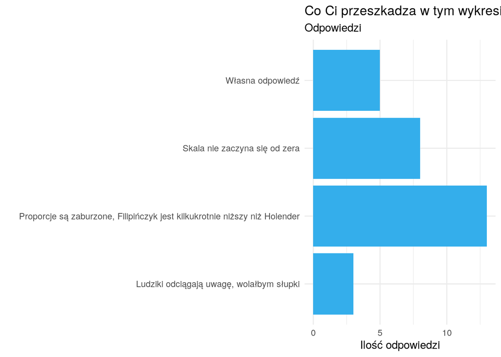

Największej ilości osób przeszkadzają proporcje, następna jest skala niezaczynająca się od zera. Pojawiły się również we własnych odpowiedziach takie, zwracające uwagę na źródło. Niektórym z nich przeszkadzało jego wyeksponowanie.

## Wykres 2

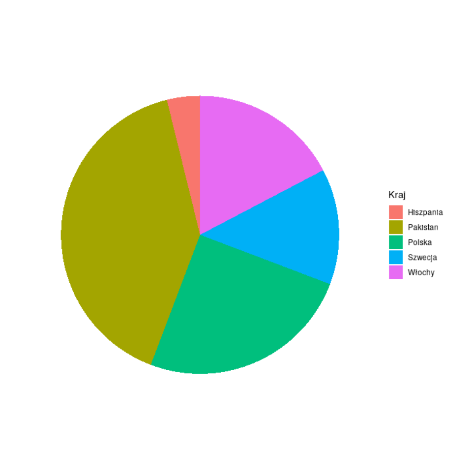

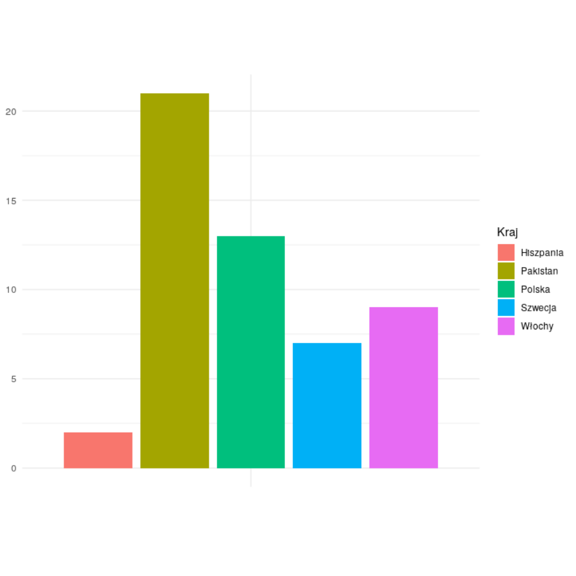

Odpowiedzi:

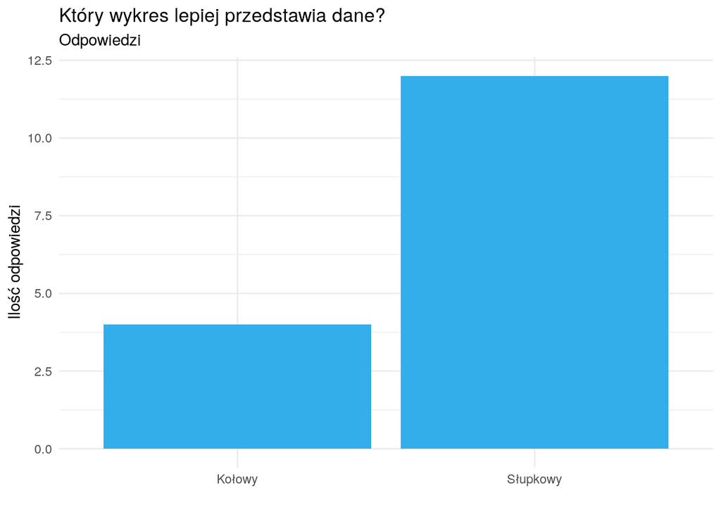

Bez większych zaskoczeń, większa część osób woli wykresy słupkowe od kołowych

## Podchwytliwe pytanie

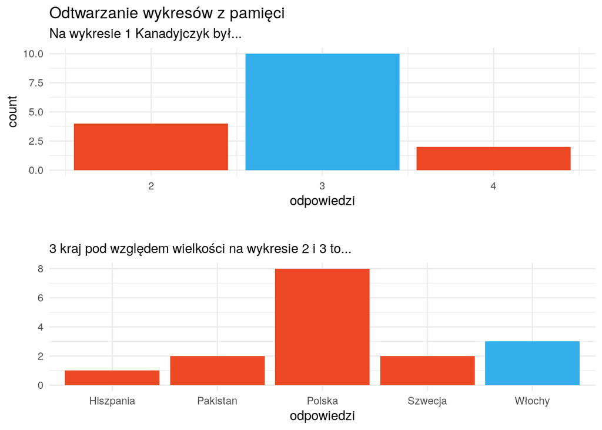

Kolor niebieski oznacza poprawną odpowiedź.

Poprzednie pytania miały niejako odwrócić uwagę od tego. Nic nie spodziewający się ankietowani mieli za zadanie odtworzyć z pamięci fakty z wykresów. Jak się okazało “ozdobniki” z pierwszego wykresu zdecydowanie pomogły zapamiętać postać 3 pod względem wysokości Kanadyjczyka, z kolei nudnie przedstawione Włochy były mylone z jakiegoś powodu z Polską. Ukazuje to, że umiejętne ozdobienie wykresu wzbudza ciekawość w ludziach, dzięki temu dłużej się przyglądają i więcej zapamiętują.